# Results - Jargon User Analytics

Jargon Analytics

# Results

## Sentiment Analysis

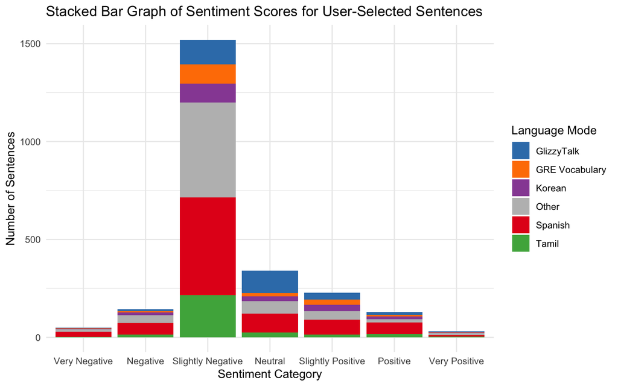

*Figure 11: Stacked bar graph showing the frequency of user-selected sentences in each sentiment category, stacked by language mode (top 5 languages shown in color, all others in grey).*

The stacked bar graph shows the overall distribution of sentiment categories, with the top 5 language modes highlighted in color and all other languages grouped in grey. This visualization highlights both the predominance of neutral and slightly negative content and the relative engagement of different language modes—including less common ones—across sentiment categories.

## LDA Analysis

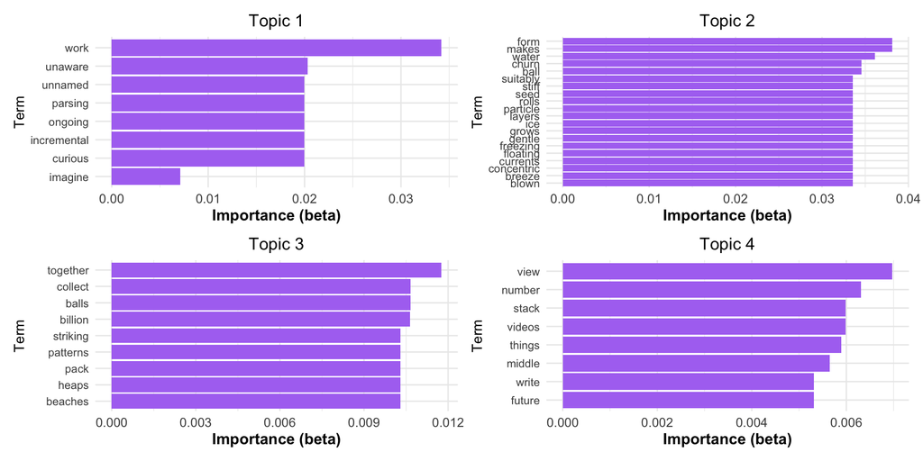

*Figure 12: Top terms for each topic identified by LDA topic modeling of user-selected sentences. Each panel shows the most important words for one topic, with x-axis numbering visible for all.*

The LDA topic modeling did not yield strong or actionable insights about the contexts or platforms where users engage with Jargon. The “Importance (beta)” values are all quite low (well below 0.05), which is typical for LDA on short texts or small datasets, but it also means that no single word dominates any topic. The topics identified are diffuse, with mostly generic or process-oriented terms. This suggests that either the user-selected content is too varied or generic for topic modeling to be effective, or that the dataset is not large or rich enough for LDA to find meaningful structure. This is a valid finding: not all analyses reveal clear patterns, and reporting this transparently demonstrates scientific rigor. It may also indicate that user engagement with Jargon is broad and not easily categorized, or that more data is needed for deeper insights.

Despite the weak themes, a tentative interpretation of the topics is as follows:

- **Topic 1:** May relate to work processes or technical tasks (e.g., “work,” “parsing,” “incremental,” “curious”).
- **Topic 2:** Appears to focus on scientific or physical phenomena, especially related to water and movement (e.g., “form,” “water,” “ice,” “currents,” “breeze”).
- **Topic 3:** Suggests group actions or collective activities (e.g., “together,” “collect,” “balls,” “patterns”).
- **Topic 4:** Includes terms that could relate to data, viewing, or content creation (e.g., “view,” “number,” “stack,” “videos,” “write”).

However, these interpretations are tentative due to the low importance values and the generic nature of the terms.

## Corelation Matrix

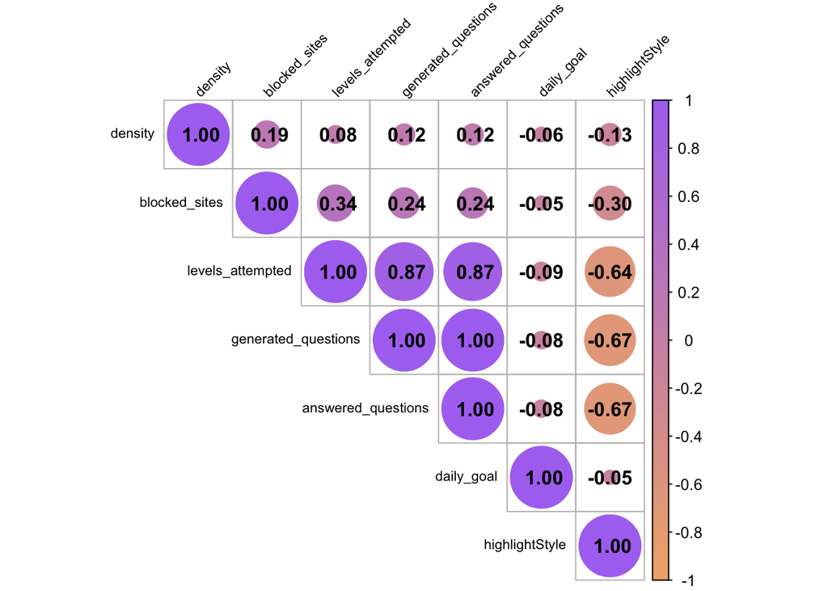

*Figure 13: Correlation matrix of user features and engagement metrics. Circle size and color indicate the strength and direction of the correlation (purple = positive, orange = negative).*

The correlation matrix reveals several notable relationships:

- **Levels Attempted, Generated Questions, and Answered Questions** are all very strongly and positively correlated (r ≈ 0.87–1.00), indicating that users who attempt more levels also generate and answer more questions—these are the most engaged users.
- **Highlight Style** shows a strong negative correlation with both Generated and Answered Questions (r ≈ -0.67), suggesting that users who prefer a particular highlight style (as encoded numerically) tend to engage less.
- **Blocked Sites** is moderately positively correlated with Levels Attempted and Engagement (r ≈ 0.24–0.34), implying that more engaged users are also more likely to block sites, possibly to focus their learning.
- **Density** and **Daily Goal** show weak or negligible correlations with engagement metrics, suggesting these settings do not strongly predict user activity in this dataset.

Overall, the strongest signals are that higher engagement (more questions and levels) tends to cluster together, and that highlight style preference is inversely related to engagement. Most other relationships are weak, indicating a diversity of user behaviors and settings.

## Feature Comparison by User Group

| term | estimate | std.error | statistic | coef.type | p.value |
| --- | --- | --- | --- | --- | --- |
| daily_goal | -0.026 | 0.011 | -2.381 | coefficient | 0.017 |
| density | 0.014 | 0.010 | 1.420 | coefficient | 0.156 |
| highlightStyleunderline | -2.746 | 1.214 | -2.262 | coefficient | 0.024 |
| Regular/Active | -1.955 | 1.345 | -1.454 | scale | 0.146 |
| Active/Very Active | 13.806 | 343.553 | 0.040 | scale | 0.968 |

*Table 10: Ordinal regression coefficients for user group score (2 = Very Active, 1 = Active, 0 = Regular)*

Table 10 presents the results of the ordinal regression model comparing user features across the three user groups. The threshold terms (e.g., ‘Regular/Active’ and ‘Active/Very Active’) represent the estimated boundaries on the latent engagement scale that separate the user groups; they are not feature effects but model cutpoints.

Among the features, two are statistically significant predictors of user group (p < 0.05):